# Lakes and wetlands analysis

The clustering algorithm cannot be changed with hclustgeo. The used method is based on the Ward methods, which we found to be the most promising in the previous section. Our function will be similar to the plotClusters from earlier, where we supply the distance matrices, the alpha value as well as some plotting specifications and output the plot with different groups having different colours.

```r
plotClustersGeo <- function(D0, D1, alpha, k, main="", xlab="", ylab="",
                            cols=c("#FFF5F0", "#FEE0D2", "#FCBBA1", "#FC9272",
                                "#FB6A4A", "#EF3B2C", "#C0181D", "#A00F15",
                                "#700000", "#400000"), alp=0.5, cex=0.5) {
ctreefull = hclustgeo(D0, D1, alpha)
ctreecut <- cutree(ctreefull, k)
sort(table(ctreecut))
names(table(ctreecut))
a<-cols[as.numeric(names(sort(table(ctreecut))))]
names(a)<-names(table(ctreecut))
ctreecut<-recode(ctreecut, !!!a, .default = NULL)
plot(data$LONG, data$LAT, col = alpha(ctreecut, alp), main=main, xlab=xlab,
     ylab=ylab, cex=cex)
}

distance2<-as.dist(DMat)
```

Firstly, let’s try to find a good value for alpha, that is, let’s try to find a good balance between the weighting of the geographical location and the characteristics of the lake.

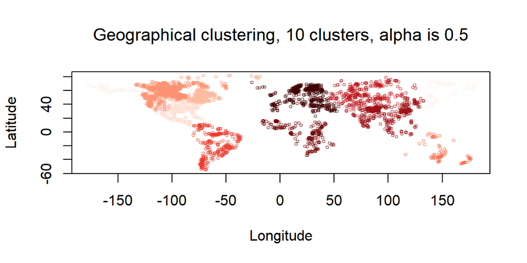

```r
plotClustersGeo(D0=distance, D1=distance2, alpha=0.5, k=10,
                main=expression(paste(Geographical~clustering, ", ", 10
                                      ~clusters, ", alpha ", is~0.5)),
                xlab="Longitude", ylab="Latitude",
                col=reds, alp=0.5)
```

Here we see that an even weighting results in the grouping being very heavily based on geographical location, with very little effect from the characteristics of the lakes.

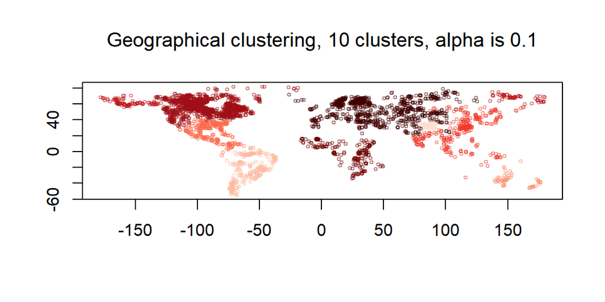

```r
plotClustersGeo(D0=distance, D1=distance2, alpha=0.1, k=10,
                main=expression(paste(Geographical~clustering, ", ", 10
                                      ~clusters, ", alpha ", is~0.1)),
                col=reds[c(1,2,3,4,5,6,7,8,9,10)], alp=0.5)
```

Now, adjusting the weighting to alpha=0.1, we start to see some effect from the characteristics of the lakes. The high altitude lakes in China are now in their own group. However, the weighting should still be more adjusted towards the characteristics having a more pronounced effect in other areas as well.

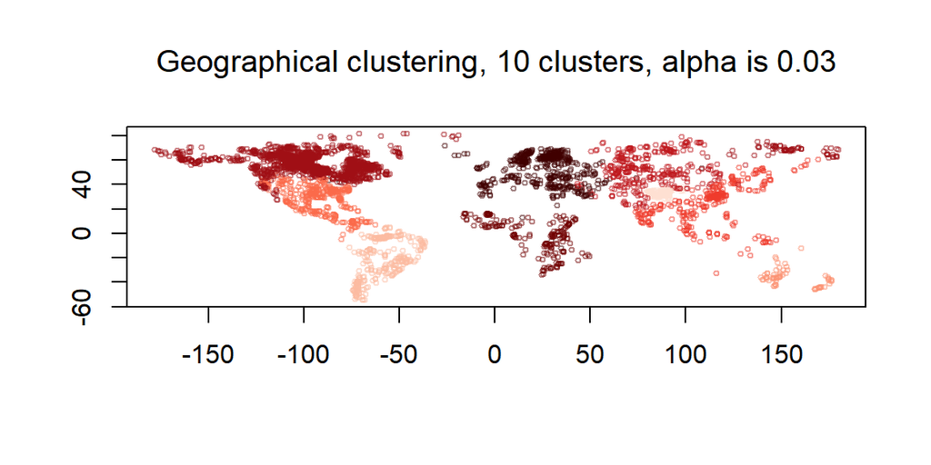

```r
plotClustersGeo(D0=distance, D1=distance2, alpha=0.03, k=10,
                main=expression(paste(Geographical~clustering, ", ", 10
                                      ~clusters, ", alpha ", is~0.03)),
                col=reds[c(1,2,9,6,5,4,7,8,3,10)], alp=0.5)
```

Here we see some lakes all over being in a different group than the lakes surrounding it, indicating it is somehow different based on its characteristics. We can try to adjust the weighting a little more to see, how it affects the number of these “outliers”. First, we set the alpha- value to 0.01.

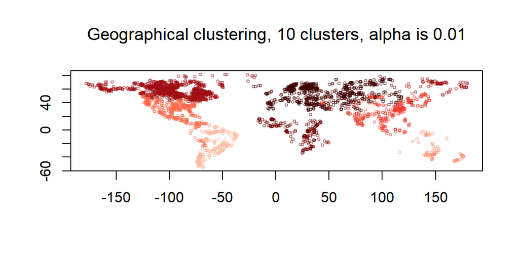

```r
plotClustersGeo(D0=distance, D1=distance2, alpha=0.01, k=10,
                main=expression(paste(Geographical~clustering, ", ", 10
                                      ~clusters, ", alpha ", is~0.01)),
                col=reds[c(7,2,1,9,6,5,4,8,3,10)], alp=0.5)
```

Here the grouping is quite similar, but some areas are clustered differently. Next, alpha is set to 0.005.

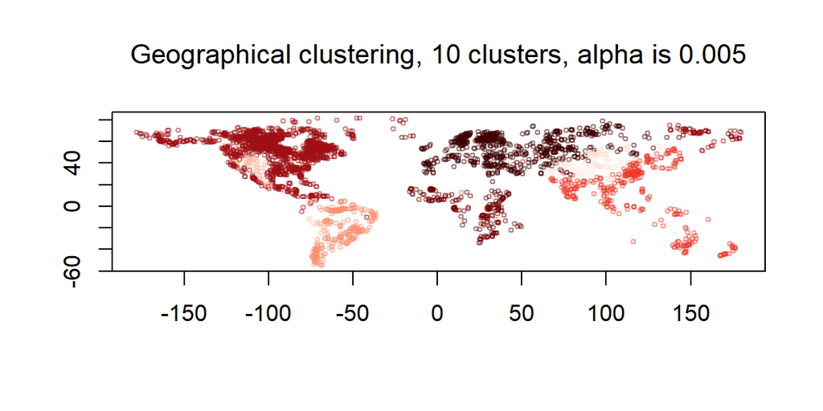

```r
plotClustersGeo(D0=distance, D1=distance2, alpha=0.005, k=10,
                main=expression(paste(Geographical~clustering, ", ", 10
                                      ~clusters, ", alpha ", is~0.005)),
                col=reds[c(7,5,4,8,9,1,10,6,2,3)], alp=0.5)
```

Now, we start to see more of the geographical groups being combined and these “outlier” groups emerging. This figure represents a quite good balance between the geographical location and characteristics of the lakes. We can try a couple more to see, if we get results similar to those using the function with no location input. Here, alpha is set to 0.001.

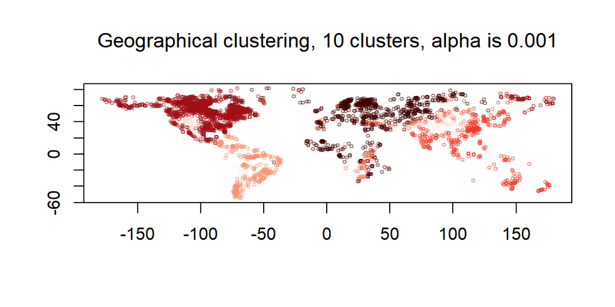

```r
plotClustersGeo(D0=distance, D1=distance2, alpha=0.001, k=10,
                main=expression(paste(Geographical~clustering, ", ", 10
                                      ~clusters, ", alpha ", is~0.001)),
                col=reds[c(7,9,3,5,6,1,8,2,4,10)], alp=0.5)
```

Here, the larger groups extend to multiple continents.

And here alpha is set to 0.0001.

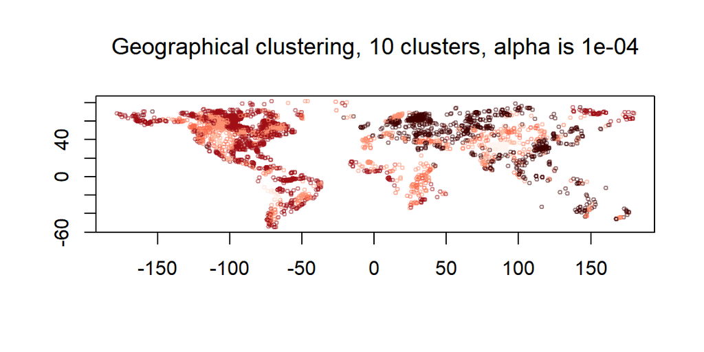

```r
plotClustersGeo(D0=distance, D1=distance2, alpha=0.0001, k=10,
                main=expression(paste(Geographical~clustering, ", ", 10
                                      ~clusters, ", alpha ", is~0.0001)),
                col=reds[c(7,9,6,1,4,10,8,3,5,2)], alp=0.5)
```

Here, most groups are stretch across all continents and there is little effect based on the geographical location.

Let’s try to adjust the amount of clusters while setting alpha to 0.005.

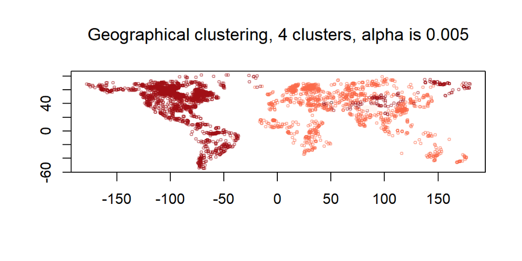

```r
plotClustersGeo(D0=distance, D1=distance2, alpha=0.005, k=4,
                main=expression(paste(Geographical~clustering, ", ", 4
                                      ~clusters, ", alpha ", is~0.005)),
                col=reds[c(10,8,1,5)], alp=0.5)
```

With four clusters, we get most of the lakes split into two groups, with some in their own group.

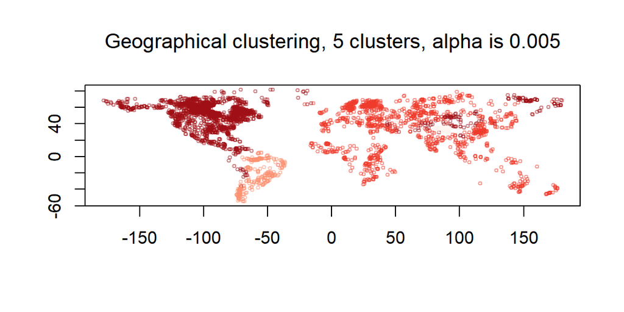

```r
plotClustersGeo(D0=distance, D1=distance2, alpha=0.005, k=5,
                main=expression(paste(Geographical~clustering, ", ", 5
                                      ~clusters, ", alpha ", is~0.005)),
                col=reds[c(2,4,1,8,6)], alp=0.5)
```

By adding one more group, the group consisting of the Americas gets split into two groups.

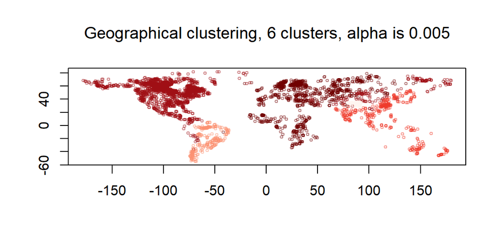

```r
plotClustersGeo(D0=distance, D1=distance2, alpha=0.005, k=6,
                main=expression(paste(Geographical~clustering, ", ", 6
                                      ~clusters, ", alpha ", is~0.005)),
                col=reds[c(2,4,1,6,8,9)], alp=0.5)
```

With six clusters, we see a further group split into two.

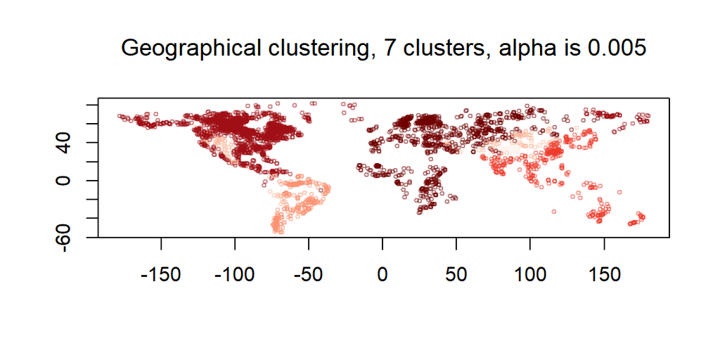

```r
plotClustersGeo(D0=distance, D1=distance2, alpha=0.005, k=7,
                main=expression(paste(Geographical~clustering, ", ", 7
                                      ~clusters, ", alpha ", is~0.005)),
                col=reds[c(2,4,3,1,6,8,9)], alp=0.5)
```

Now, with seven clusters we get another group consisting of lakes from all over the map, predominantly mountain regions in the Americas and Asia.

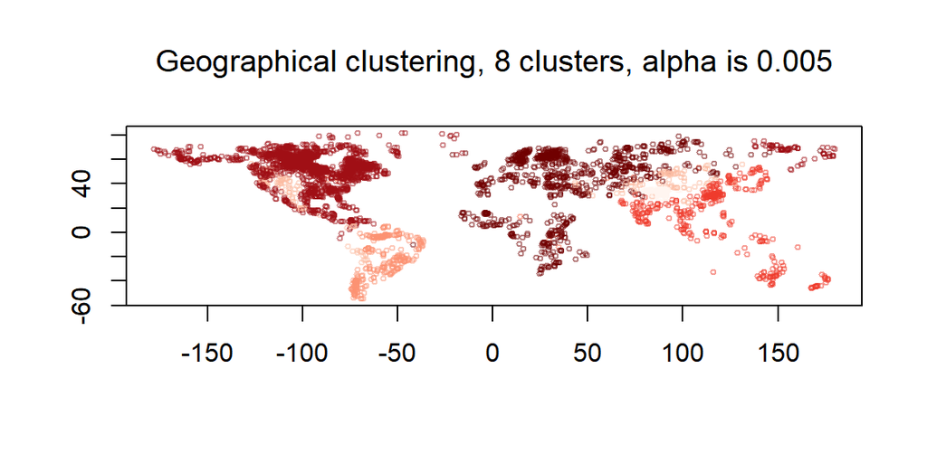

```r
plotClustersGeo(D0=distance, D1=distance2, alpha=0.005, k=8,
                main=expression(paste(Geographical~clustering, ", ", 8
                                      ~clusters, ", alpha ", is~0.005)),
                col=reds[c(2,5,4,3,1,6,8,9)], alp=0.5)
```

With eight clusters, we get a further group of lakes all over the map, this time the connection between them is not that clear.